# Coffee data

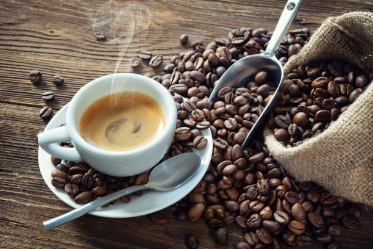

Like we Brazilians like to say: anytime is a good time for coffee (even at night)

Yes, Brazilians are obsessed over coffee. But we are not alone in this, so is the whole world.  
Well, let’s start our data exploring.

```r
library(dplyr)
library(ggplot2)
```

# Scenario

First let’s imagine you are about to open your new coffeshop, LateCoffes. Congratulations! You definitely are very busy as opening a store is never an easy task. Right now, you a huge decision to make that choosing which coffees you are going to sell in your shop. Let’s say you decide to start with 3 brands. But how are you going to make the decision from which coffee seller to buy?

I believe we could start by analyzing:

- countries of origin of the coffee
- total cup points of the coffee.

Then my first question is:

- from which country should I buy coffee?

Alright, now that we have decided our criteria, let’s import some data, shall we?

## Importing our data

```r
library(tidytuesdayR)
data <- tidytuesdayR::tt_load(2020, week = 28)
```

```
--- Compiling #TidyTuesday Information for 2020-07-07 ----
--- There is 1 file available ---
--- Starting Download ---
```

```
--- Download complete ---
```

```r
coffee_data <- data$coffee_ratings
head(coffee_data)
```

| total_cup_points | species | owner | country_of_origin | farm_name | lot_number | mill | ico_number | company | altitude | region | producer | number_of_bags | bag_weight | in_country_partner | harvest_year | grading_date | owner_1 | variety | processing_method | aroma | flavor | aftertaste | acidity | body | balance | uniformity | clean_cup | sweetness | cupper_points | … |
| --- | --- | --- | --- | --- | --- | --- | --- | --- | --- | --- | --- | --- | --- | --- | --- | --- | --- | --- | --- | --- | --- | --- | --- | --- | --- | --- | --- | --- | --- | --- |
| 90.58 | Arabica | metad plc | Ethiopia | metad plc | NA | metad plc | 2014/2015 | metad agricultural developmet plc | 1950-2200 | guji-hambela | METAD PLC | 300 | 60 kg | METAD Agricultural Development plc | 2014 | April 4th, 2015 | metad plc | NA | Washed / Wet | 8.67 | 8.83 | 8.67 | 8.75 | 8.50 | 8.42 | 10 | 10 | 10 | 8.75 | … |
| 89.92 | Arabica | metad plc | Ethiopia | metad plc | NA | metad plc | 2014/2015 | metad agricultural developmet plc | 1950-2200 | guji-hambela | METAD PLC | 300 | 60 kg | METAD Agricultural Development plc | 2014 | April 4th, 2015 | metad plc | Other | Washed / Wet | 8.75 | 8.67 | 8.50 | 8.58 | 8.42 | 8.42 | 10 | 10 | 10 | 8.58 | … |
| 89.75 | Arabica | grounds for health admin | Guatemala | san marcos barrancas "san cristobal cuch | NA | NA | NA | NA | 1600 - 1800 m | NA | NA | 5 | 1 | Specialty Coffee Association | NA | May 31st, 2010 | Grounds for Health Admin | Bourbon | NA | 8.42 | 8.50 | 8.42 | 8.42 | 8.33 | 8.42 | 10 | 10 | 10 | 9.25 | … |
| 89.00 | Arabica | yidnekachew dabessa | Ethiopia | yidnekachew dabessa coffee plantation | NA | wolensu | NA | yidnekachew debessa coffee plantation | 1800-2200 | oromia | Yidnekachew Dabessa Coffee Plantation | 320 | 60 kg | METAD Agricultural Development plc | 2014 | March 26th, 2015 | Yidnekachew Dabessa | NA | Natural / Dry | 8.17 | 8.58 | 8.42 | 8.42 | 8.50 | 8.25 | 10 | 10 | 10 | 8.67 | … |
| 88.83 | Arabica | metad plc | Ethiopia | metad plc | NA | metad plc | 2014/2015 | metad agricultural developmet plc | 1950-2200 | guji-hambela | METAD PLC | 300 | 60 kg | METAD Agricultural Development plc | 2014 | April 4th, 2015 | metad plc | Other | Washed / Wet | 8.25 | 8.50 | 8.25 | 8.50 | 8.42 | 8.33 | 10 | 10 | 10 | 8.58 | … |
| 88.83 | Arabica | ji-ae ahn | Brazil | NA | NA | NA | NA | NA | NA | NA | NA | 100 | 30 kg | Specialty Coffee Institute of Asia | 2013 | September 3rd, 2013 | Ji-Ae Ahn | NA | Natural / Dry | 8.58 | 8.42 | 8.42 | 8.50 | 8.25 | 8.33 | 10 | 10 | 10 | 8.33 | … |

This dataset is huge! How many variables do we have here?

```r
dim(coffee_data)
```

```
[1] 1339   43
```

Wow! So we have 43 variables and 1339 entries. We surely can have some fun exploring this dataset. But let’s select some interesting variables. What are the variables names?

```r
names(coffee_data)
```

```
 [1] "total_cup_points"      "species"               "owner"                 "country_of_origin"
 [5] "farm_name"             "lot_number"            "mill"                  "ico_number"
 [9] "company"               "altitude"              "region"                "producer"
[13] "number_of_bags"        "bag_weight"            "in_country_partner"    "harvest_year"
[17] "grading_date"          "owner_1"               "variety"               "processing_method"
[21] "aroma"                 "flavor"                "aftertaste"            "acidity"
[25] "body"                  "balance"               "uniformity"            "clean_cup"
[29] "sweetness"             "cupper_points"         "moisture"              "category_one_defects"
[33] "quakers"               "color"                 "category_two_defects"  "expiration"
[37] "certification_body"    "certification_address" "certification_contact" "unit_of_measurement"
[41] "altitude_low_meters"   "altitude_high_meters"  "altitude_mean_meters"
```

### Selecting countries that have at least 20 occurrences in our df

```r
filtered_df <- coffee_data %>%
  group_by(country_of_origin) %>%
  filter(n()>=20)

filtered_df
```

| total_cup_points | species | owner | country_of_origin | farm_name | lot_number | mill | ico_number | company | altitude | region | producer | number_of_bags | bag_weight | in_country_partner | harvest_year | grading_date | owner_1 | variety | processing_method | aroma | flavor | aftertaste | acidity | body | balance | uniformity | clean_cup | sweetness | cupper_points | … |
| --- | --- | --- | --- | --- | --- | --- | --- | --- | --- | --- | --- | --- | --- | --- | --- | --- | --- | --- | --- | --- | --- | --- | --- | --- | --- | --- | --- | --- | --- | --- |
| 90.58 | Arabica | metad plc | Ethiopia | metad plc | NA | metad plc | 2014/2015 | metad agricultural developmet plc | 1950-2200 | guji-hambela | METAD PLC | 300 | 60 kg | METAD Agricultural Development plc | 2014 | April 4th, 2015 | metad plc | NA | Washed / Wet | 8.67 | 8.83 | 8.67 | 8.75 | 8.50 | 8.42 | 10.00 | 10.00 | 10.00 | 8.75 | … |
| 89.92 | Arabica | metad plc | Ethiopia | metad plc | NA | metad plc | 2014/2015 | metad agricultural developmet plc | 1950-2200 | guji-hambela | METAD PLC | 300 | 60 kg | METAD Agricultural Development plc | 2014 | April 4th, 2015 | metad plc | Other | Washed / Wet | 8.75 | 8.67 | 8.50 | 8.58 | 8.42 | 8.42 | 10.00 | 10.00 | 10.00 | 8.58 | … |
| 89.75 | Arabica | grounds for health admin | Guatemala | san marcos barrancas "san cristobal cuch | NA | NA | NA | NA | 1600 - 1800 m | NA | NA | 5 | 1 | Specialty Coffee Association | NA | May 31st, 2010 | Grounds for Health Admin | Bourbon | NA | 8.42 | 8.50 | 8.42 | 8.42 | 8.33 | 8.42 | 10.00 | 10.00 | 10.00 | 9.25 | … |
| 89.00 | Arabica | yidnekachew dabessa | Ethiopia | yidnekachew dabessa coffee plantation | NA | wolensu | NA | yidnekachew debessa coffee plantation | 1800-2200 | oromia | Yidnekachew Dabessa Coffee Plantation | 320 | 60 kg | METAD Agricultural Development plc | 2014 | March 26th, 2015 | Yidnekachew Dabessa | NA | Natural / Dry | 8.17 | 8.58 | 8.42 | 8.42 | 8.50 | 8.25 | 10.00 | 10.00 | 10.00 | 8.67 | … |
| 88.83 | Arabica | metad plc | Ethiopia | metad plc | NA | metad plc | 2014/2015 | metad agricultural developmet plc | 1950-2200 | guji-hambela | METAD PLC | 300 | 60 kg | METAD Agricultural Development plc | 2014 | April 4th, 2015 | metad plc | Other | Washed / Wet | 8.25 | 8.50 | 8.25 | 8.50 | 8.42 | 8.33 | 10.00 | 10.00 | 10.00 | 8.58 | … |
| 88.83 | Arabica | ji-ae ahn | Brazil | NA | NA | NA | NA | NA | NA | NA | NA | 100 | 30 kg | Specialty Coffee Institute of Asia | 2013 | September 3rd, 2013 | Ji-Ae Ahn | NA | Natural / Dry | 8.58 | 8.42 | 8.42 | 8.50 | 8.25 | 8.33 | 10.00 | 10.00 | 10.00 | 8.33 | … |
| 88.67 | Arabica | ethiopia commodity exchange | Ethiopia | aolme | NA | c.p.w.e | 010/0338 | NA | 1570-1700 | oromia | Bazen Agricultural & Industrial Dev't Plc | 300 | 60 kg | Ethiopia Commodity Exchange | March 2010 | September 2nd, 2010 | Ethiopia Commodity Exchange | NA | NA | 8.25 | 8.33 | 8.50 | 8.42 | 8.33 | 8.50 | 10.00 | 10.00 | 9.33 | 9.00 | … |
| 88.42 | Arabica | ethiopia commodity exchange | Ethiopia | aolme | NA | c.p.w.e | 010/0338 | NA | 1570-1700 | oromiya | Bazen Agricultural & Industrial Dev't Plc | 300 | 60 kg | Ethiopia Commodity Exchange | March 2010 | September 2nd, 2010 | Ethiopia Commodity Exchange | NA | NA | 8.67 | 8.67 | 8.58 | 8.42 | 8.33 | 8.42 | 9.33 | 10.00 | 9.33 | 8.67 | … |
| 88.25 | Arabica | diamond enterprise plc | Ethiopia | tulla coffee farm | NA | tulla coffee farm | 2014/15 | diamond enterprise plc | 1795-1850 | snnp/kaffa zone,gimbowereda | Diamond Enterprise Plc | 50 | 60 kg | METAD Agricultural Development plc | 2014 | March 30th, 2015 | Diamond Enterprise Plc | Other | Natural / Dry | 8.08 | 8.58 | 8.50 | 8.50 | 7.67 | 8.42 | 10.00 | 10.00 | 10.00 | 8.50 | … |
| 88.08 | Arabica | mohammed lalo | Ethiopia | fahem coffee plantation | NA | NA | NA | fahem coffee plantation | 1855-1955 | oromia | Fahem Coffee Plantation | 300 | 60 kg | METAD Agricultural Development plc | 2014 | March 27th, 2015 | Mohammed Lalo | NA | Natural / Dry | 8.17 | 8.67 | 8.25 | 8.50 | 7.75 | 8.17 | 10.00 | 10.00 | 10.00 | 8.58 | … |

[output cut: 990 more lines]

```r
NA
```

We have several producers from different countries with their total cup points data. How can we make a decision which country has the better coffee overall?

```r
grouped_df <- aggregate(total_cup_points ~ country_of_origin, filtered_df, sd)
# ordenando e pegando os menores sd
sorted_grouped_df <- grouped_df[order(grouped_df$total_cup_points),]
top15 <- head(sorted_grouped_df, 10)
# fazendo um vetor com os nomes da coluna de country_of_origin
top15_names <- top15$country_of_origin
filteredf2 <- filtered_df %>% filter(country_of_origin %in% top15_names)
filteredf2
```

| total_cup_points | species | owner | country_of_origin | farm_name | lot_number | mill | ico_number | company | altitude | region | producer | number_of_bags | bag_weight | in_country_partner | harvest_year | grading_date | owner_1 | variety | processing_method | aroma | flavor | aftertaste | acidity | body | balance | uniformity | clean_cup | sweetness | cupper_points | … |
| --- | --- | --- | --- | --- | --- | --- | --- | --- | --- | --- | --- | --- | --- | --- | --- | --- | --- | --- | --- | --- | --- | --- | --- | --- | --- | --- | --- | --- | --- | --- |
| 90.58 | Arabica | metad plc | Ethiopia | metad plc | NA | metad plc | 2014/2015 | metad agricultural developmet plc | 1950-2200 | guji-hambela | METAD PLC | 300 | 60 kg | METAD Agricultural Development plc | 2014 | April 4th, 2015 | metad plc | NA | Washed / Wet | 8.67 | 8.83 | 8.67 | 8.75 | 8.50 | 8.42 | 10.00 | 10.00 | 10.00 | 8.75 | … |
| 89.92 | Arabica | metad plc | Ethiopia | metad plc | NA | metad plc | 2014/2015 | metad agricultural developmet plc | 1950-2200 | guji-hambela | METAD PLC | 300 | 60 kg | METAD Agricultural Development plc | 2014 | April 4th, 2015 | metad plc | Other | Washed / Wet | 8.75 | 8.67 | 8.50 | 8.58 | 8.42 | 8.42 | 10.00 | 10.00 | 10.00 | 8.58 | … |
| 89.00 | Arabica | yidnekachew dabessa | Ethiopia | yidnekachew dabessa coffee plantation | NA | wolensu | NA | yidnekachew debessa coffee plantation | 1800-2200 | oromia | Yidnekachew Dabessa Coffee Plantation | 320 | 60 kg | METAD Agricultural Development plc | 2014 | March 26th, 2015 | Yidnekachew Dabessa | NA | Natural / Dry | 8.17 | 8.58 | 8.42 | 8.42 | 8.50 | 8.25 | 10.00 | 10.00 | 10.00 | 8.67 | … |
| 88.83 | Arabica | metad plc | Ethiopia | metad plc | NA | metad plc | 2014/2015 | metad agricultural developmet plc | 1950-2200 | guji-hambela | METAD PLC | 300 | 60 kg | METAD Agricultural Development plc | 2014 | April 4th, 2015 | metad plc | Other | Washed / Wet | 8.25 | 8.50 | 8.25 | 8.50 | 8.42 | 8.33 | 10.00 | 10.00 | 10.00 | 8.58 | … |
| 88.83 | Arabica | ji-ae ahn | Brazil | NA | NA | NA | NA | NA | NA | NA | NA | 100 | 30 kg | Specialty Coffee Institute of Asia | 2013 | September 3rd, 2013 | Ji-Ae Ahn | NA | Natural / Dry | 8.58 | 8.42 | 8.42 | 8.50 | 8.25 | 8.33 | 10.00 | 10.00 | 10.00 | 8.33 | … |
| 88.67 | Arabica | ethiopia commodity exchange | Ethiopia | aolme | NA | c.p.w.e | 010/0338 | NA | 1570-1700 | oromia | Bazen Agricultural & Industrial Dev't Plc | 300 | 60 kg | Ethiopia Commodity Exchange | March 2010 | September 2nd, 2010 | Ethiopia Commodity Exchange | NA | NA | 8.25 | 8.33 | 8.50 | 8.42 | 8.33 | 8.50 | 10.00 | 10.00 | 9.33 | 9.00 | … |
| 88.42 | Arabica | ethiopia commodity exchange | Ethiopia | aolme | NA | c.p.w.e | 010/0338 | NA | 1570-1700 | oromiya | Bazen Agricultural & Industrial Dev't Plc | 300 | 60 kg | Ethiopia Commodity Exchange | March 2010 | September 2nd, 2010 | Ethiopia Commodity Exchange | NA | NA | 8.67 | 8.67 | 8.58 | 8.42 | 8.33 | 8.42 | 9.33 | 10.00 | 9.33 | 8.67 | … |
| 88.25 | Arabica | diamond enterprise plc | Ethiopia | tulla coffee farm | NA | tulla coffee farm | 2014/15 | diamond enterprise plc | 1795-1850 | snnp/kaffa zone,gimbowereda | Diamond Enterprise Plc | 50 | 60 kg | METAD Agricultural Development plc | 2014 | March 30th, 2015 | Diamond Enterprise Plc | Other | Natural / Dry | 8.08 | 8.58 | 8.50 | 8.50 | 7.67 | 8.42 | 10.00 | 10.00 | 10.00 | 8.50 | … |
| 88.08 | Arabica | mohammed lalo | Ethiopia | fahem coffee plantation | NA | NA | NA | fahem coffee plantation | 1855-1955 | oromia | Fahem Coffee Plantation | 300 | 60 kg | METAD Agricultural Development plc | 2014 | March 27th, 2015 | Mohammed Lalo | NA | Natural / Dry | 8.17 | 8.67 | 8.25 | 8.50 | 7.75 | 8.17 | 10.00 | 10.00 | 10.00 | 8.58 | … |
| 87.83 | Arabica | ethiopia commodity exchange | Ethiopia | aolme | NA | c.p.w.e | 010/0338 | NA | 1570-1700 | oromiya | Bazen Agricultural & Industrial Dev't Plc | 300 | 60 kg | Ethiopia Commodity Exchange | March 2010 | August 31st, 2010 | Ethiopia Commodity Exchange | NA | NA | 8.25 | 8.33 | 8.50 | 8.25 | 8.58 | 8.75 | 9.33 | 10.00 | 9.33 | 8.50 | … |

[output cut: 629 more lines]

### Let’s take a look at the distribution of these countries

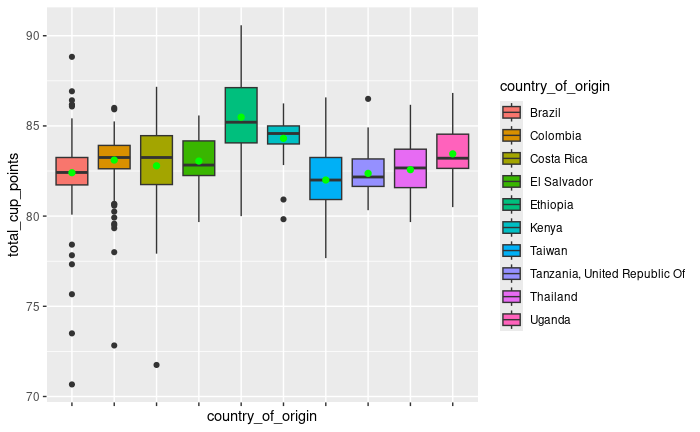

```r
p <- ggplot(filteredf2, aes(x=country_of_origin, y=total_cup_points, fill=country_of_origin)) + geom_boxplot() + stat_summary(fun.y=mean, geom="point", shape=20, size=3, color="green", fill="green") + theme(axis.text.x = element_blank() )
p
```

```r
median_agg <- aggregate(total_cup_points ~ country_of_origin, filtered_df1, median)
head(median_agg[order(median_agg$total_cup_points),], 15)$country_of_origin
```

[output not shown]

```r
p <- ggplot(filteredf2, aes(x=country_of_origin, y=total_cup_points, fill=country_of_origin)) + geom_violin() +
  theme(axis.title.x=element_blank(),
        axis.text.x=element_blank(),
        axis.ticks.x=element_blank())

p
```

[output not shown]

```r
p <- ggplot(filteredf2, aes(x=country_of_origin, y=total_cup_points, fill=country_of_origin)) + geom_boxplot() +
    stat_summary(fun.y=mean, geom="point", shape=20, size=3, color="red", fill="red")

p
```

[output not shown]

But let’s begin by putting our descriptive statistical skills in practice first.